# Visualising data (ggplot)

November 1st 2018

## Before we move into ggplot

## Wide vs long data format

```r
wide_data = tibble(samples = str_c('smpl_', 1:5), var_1 = round(rnorm(5),2),
                   var_2 = round(rnorm(5),2), var_3 = round(rnorm(5),2))
wide_data
```

```
## # A tibble: 5 x 4
##   samples var_1 var_2 var_3
##   <chr>   <dbl> <dbl> <dbl>
## 1 smpl_1  -0.89  0.93  0.67
## 2 smpl_2  -0.56 -1.1   0.76
## 3 smpl_3  -0.45 -1.74 -0.32
## 4 smpl_4  -0.36 -0.73  1.75
## 5 smpl_5   1.13  0.64  0.78
```

Recall, I told you that each row is an observation and each column is a variable? Well…

## There is another Skywalker (Sorry)

We can convert the wide format to what is known as long format like so:

```r
long_data = wide_data %>% gather(key = var, value = value, -samples)
long_data
```

```
## # A tibble: 15 x 3
##    samples var   value
##    <chr>   <chr> <dbl>
##  1 smpl_1  var_1 -0.89
##  2 smpl_2  var_1 -0.56
##  3 smpl_3  var_1 -0.45
##  4 smpl_4  var_1 -0.36
##  5 smpl_5  var_1  1.13
##  6 smpl_1  var_2  0.93
##  7 smpl_2  var_2 -1.1
##  8 smpl_3  var_2 -1.74
##  9 smpl_4  var_2 -0.73
## 10 smpl_5  var_2  0.64
## 11 smpl_1  var_3  0.67
## 12 smpl_2  var_3  0.76
## 13 smpl_3  var_3 -0.32
## 14 smpl_4  var_3  1.75
## 15 smpl_5  var_3  0.78
```

## Long format

This is particular useful if you have longitudinal data, as it allows you to flatten the data from a cube with time slices to a matrix. Example:

```r
wide_data_t1 = tibble(samples = str_c('smpl_', 1:3), var_1 = round(rnorm(3),2),
                      var_2 = round(rnorm(3),2))
wide_data_t2 = tibble(samples = str_c('smpl_', 1:3), var_1 = round(rnorm(3),2),
                      var_2 = round(rnorm(3),2))
wide_data_t3 = tibble(samples = str_c('smpl_', 1:3), var_1 = round(rnorm(3),2),
                      var_2 = round(rnorm(3),2))
```

Add a `time point` variable

```r
wide_data_t1 = wide_data_t1 %>% mutate(time_point = 1)
wide_data_t2 = wide_data_t2 %>% mutate(time_point = 2)
wide_data_t3 = wide_data_t3 %>% mutate(time_point = 3)
```

Bind the three data frames and convert to long format

```r
long_data_t = bind_rows(wide_data_t1, wide_data_t2, wide_data_t3) %>%
  gather(key = var, value = value, -samples, -time_point)
```

## Long format

```r
long_data_t
```

```
## # A tibble: 18 x 4
##    samples time_point var    value
##    <chr>        <dbl> <chr>  <dbl>
##  1 smpl_1           1 var_1  0.02
##  2 smpl_2           1 var_1 -2.08
##  3 smpl_3           1 var_1  0.43
##  4 smpl_1           2 var_1  0.14
##  5 smpl_2           2 var_1 -1.5
##  6 smpl_3           2 var_1 -0.66
##  7 smpl_1           3 var_1 -0.35
##  8 smpl_2           3 var_1 -1.42
##  9 smpl_3           3 var_1  1.12
## 10 smpl_1           1 var_2  0.74
## 11 smpl_2           1 var_2  1.19
## 12 smpl_3           1 var_2 -1.07
## 13 smpl_1           2 var_2  1.14
## 14 smpl_2           2 var_2 -1.11
## 15 smpl_3           2 var_2 -0.5
## 16 smpl_1           3 var_2 -0.35
## 17 smpl_2           3 var_2  0.580
## 18 smpl_3           3 var_2 -0.44
```

## Long format

Depending on what you want to visualise, these long-to-wide or wide-to-long conversion, may have to be used.

So, let us just convert the `long_data_t` back to wide format, so you can see how that is done:

```r
long_data_t %>% spread(key = var, value = value)
```

```
## # A tibble: 9 x 4
##   samples time_point var_1  var_2
##   <chr>        <dbl> <dbl>  <dbl>
## 1 smpl_1           1  0.02  0.74
## 2 smpl_1           2  0.14  1.14
## 3 smpl_1           3 -0.35 -0.35
## 4 smpl_2           1 -2.08  1.19
## 5 smpl_2           2 -1.5  -1.11
## 6 smpl_2           3 -1.42  0.580
## 7 smpl_3           1  0.43 -1.07
## 8 smpl_3           2 -0.66 -0.5
## 9 smpl_3           3  1.12 -0.44
```

## Summary - Long and wide data

- Convert from wide to long: `gather()`
- Convert from long to wide: `spread()`

See previous slides for examples.

Moving on to data visualisation…

## Data Visualisation using ggplot

## Cliché: A picture says more than 1,000 numbers

Except

## Cliché: A picture says more than 1,000 numbers

Except pie charts… This, this is the only valid use of a pie chart I have seen:

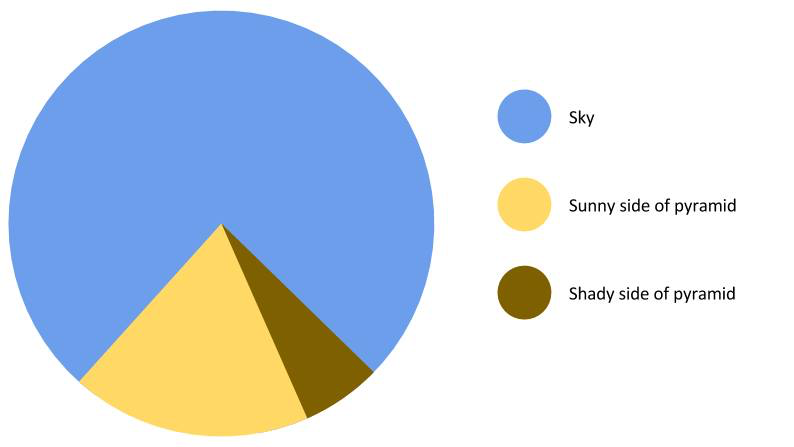

## What is `ggplot`?

- The 'gg' in `ggplot` stands for Grammar-of-Graphics.
- "A grammar of graphics is a tool that enables us to concisely describe the components of a graphic" Hadley Wickham. A layered grammar of graphics. Journal of Computational and Graphical Statistics, vol. 19, no. 1, pp. 3–28, 2010.
- So, a structured framework for building graphical representations of data
- Let us start with some examples

## Example data for data visualisation

We will use the `ToothGrowth` data set "The Effect of Vitamin C on Tooth Growth in Guinea Pigs", 60 observations of 3 variables:

- `len`, numeric, Tooth length
- `supp`, factor, Supplement type (VC = ascorbic acid or OJ = Orange Juice)
- `dose`, numeric, Dose in milligrams/day

```r
ToothGrowth %>% head(5)
```

```
##    len supp dose
## 1  4.2   VC  0.5
## 2 11.5   VC  0.5
## 3  7.3   VC  0.5
## 4  5.8   VC  0.5
## 5  6.4   VC  0.5
```

## Example data for data visualisation

We can use the `count()` function to investigate how the 60 Guniea Pigs are distributed in the `supp` and `dose` groups:

```r
ToothGrowth %>% count(supp, dose)
```

```
## # A tibble: 6 x 3
##   supp   dose     n
##   <fct> <dbl> <int>
## 1 OJ      0.5    10
## 2 OJ      1      10
## 3 OJ      2      10
## 4 VC      0.5    10
## 5 VC      1      10
## 6 VC      2      10
```

## A basic barchart

We can visulise the counts using a simple barchart:

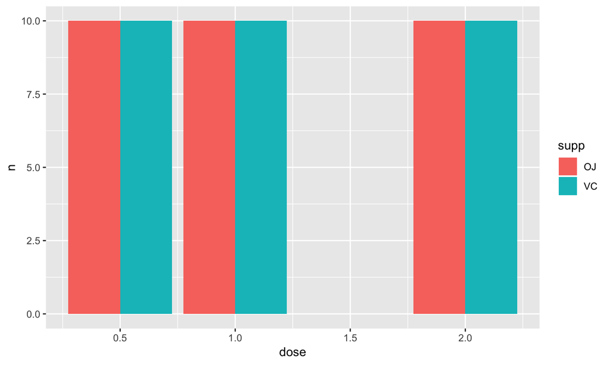

```r
ToothGrowth %>% count(dose, supp) %>%
  ggplot(aes(x = dose, y = n, fill = supp)) +
  geom_col(position = 'dodge')
```

## A basic scatterplot

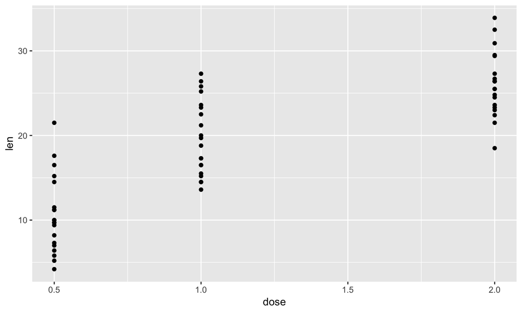

```r
ToothGrowth %>%
  ggplot(mapping = aes(x = dose, y = len)) +
  geom_point()
```

It seems that dose has an effect (Note how layers are added using `+`), let us look at it in another way

## A basic boxplot

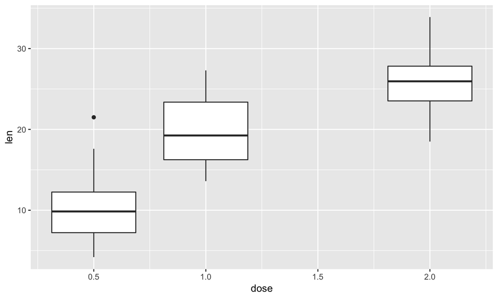

```r
ToothGrowth %>%
  ggplot(mapping = aes(x = dose, y = len, group = dose)) +
  geom_boxplot()
```

Looks better, but it is difficult to make out the underlying distributions

## A basic histogram

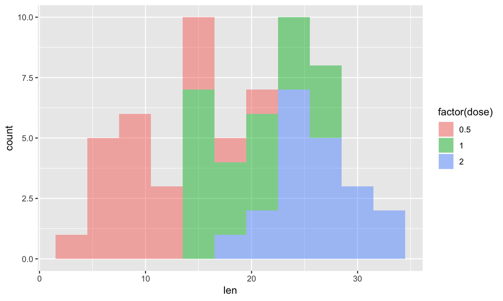

```r
ToothGrowth %>%
  ggplot(mapping = aes(x = len, fill = factor(dose))) +
  geom_histogram(alpha = 0.5, binwidth = 3)
```

Not very informative, let us look at a density plot instead

## A basic density plot

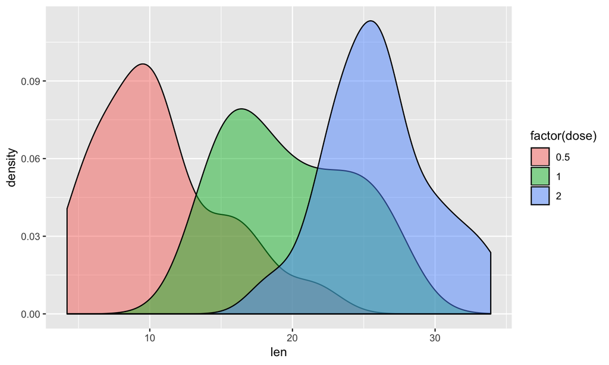

```r
ToothGrowth %>% ggplot(mapping = aes(x = len, fill = factor(dose))) + geom_density(alpha = 0.5)
```

It is a bit messy, that the densities are covering each other, try a violin plot

## A basic violinplot

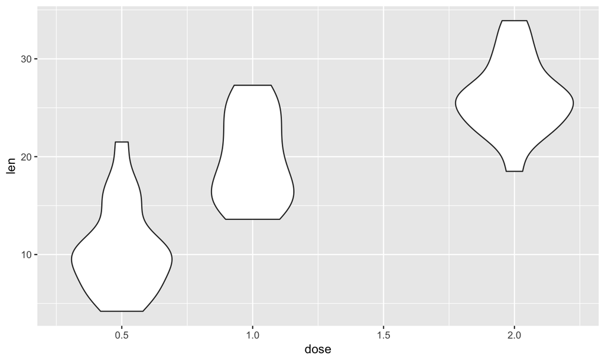

```r
ToothGrowth %>%
  ggplot(mapping = aes(x = dose, y = len, group = dose)) +
  geom_violin()
```

But wait, we have different types of supplements

## A grouped violinplot

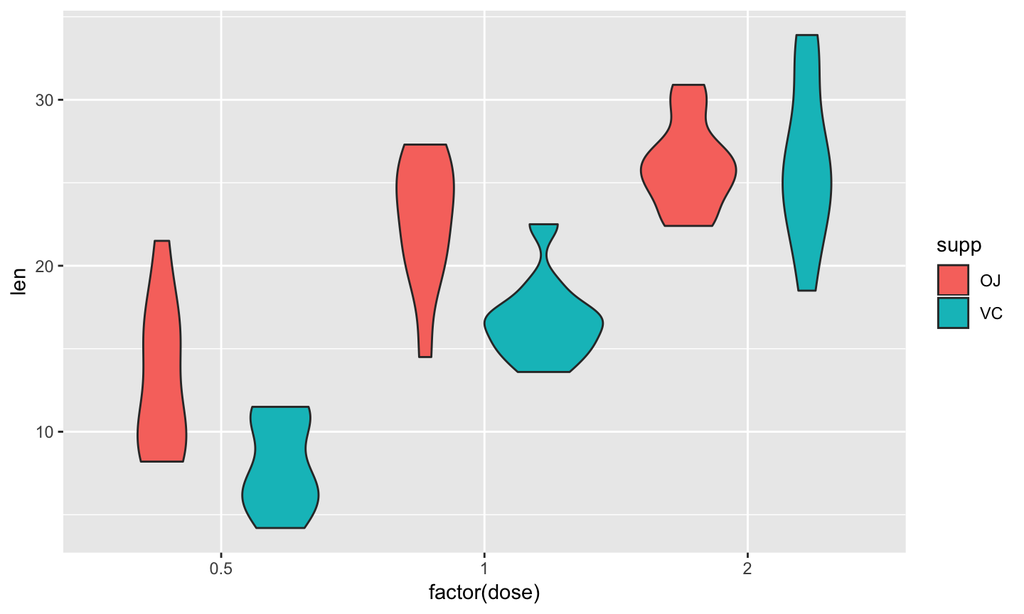

```r
ToothGrowth %>%
  ggplot(mapping = aes(x = factor(dose), y = len, fill = supp)) +
  geom_violin()
```

It seems, that not only is there an effect of dose, but also the supplement type

## A grouped boxplot

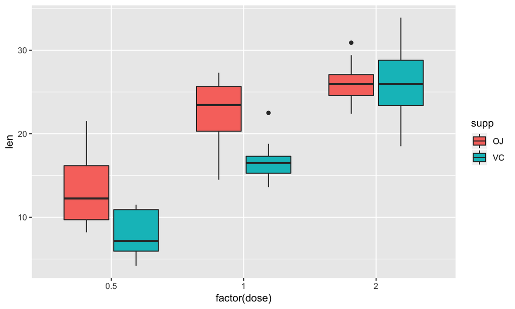

```r
ToothGrowth %>%
  ggplot(mapping = aes(x = factor(dose), y = len, fill = supp)) +
  geom_boxplot()
```

## A scatter plot with groups and models

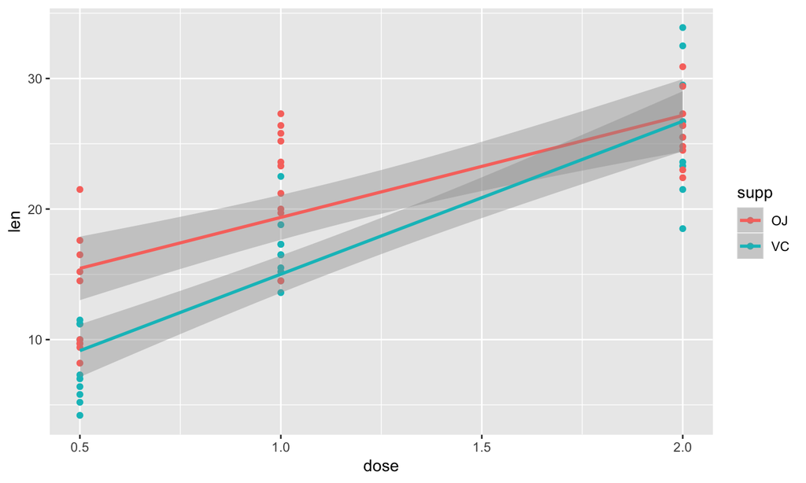

```r
ToothGrowth %>%
  ggplot(mapping = aes(x = dose, y = len, colour = supp)) +
  geom_point() +
  geom_smooth(method = "lm")
```

## A scatter plot with facets, models and densities

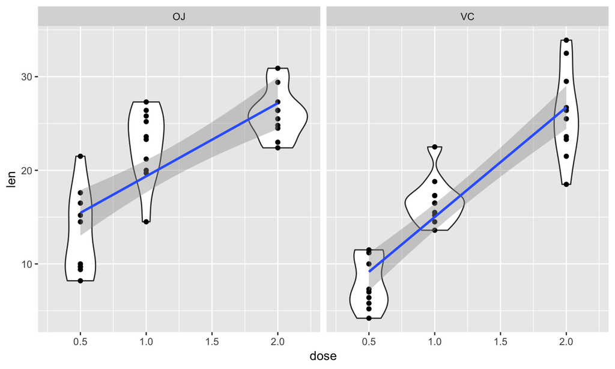

```r
ToothGrowth %>%
  ggplot(mapping = aes(x = dose, y = len)) +
  geom_violin(mapping = aes(x = dose, y = len, group = dose)) +
  geom_point() +
  geom_smooth(method = "lm") +
  facet_wrap(~supp, nrow = 1)
```

## In summary

We hope it is evident just how easy ggplot makes publication ready data viualisations and how readable the code is!

Now, it is time for exercises!